# Longitudinal data analysis and mixed models

2023-10-28T17:26:23-05:00

Understanding the overall progression of disease is critical to the timing of therapeutic interventions and design of effective clinical trials. Disease progression can be assessed with longitudinal study designs in which outcomes are measured repeatedly over time and are assessed with respect to risk factors, either measured repeatedly or at baseline. Longitudinal data allows researchers to assess temporal disease aspects, but the analysis is complicated by complex correlation structures, irregularly spaced visits, missing data, and mixtures of time-varying and static covariate effects.

Read more on this [here.](https://www.ncbi.nlm.nih.gov/pmc/articles/PMC5633048/table/T1/?report=objectonly)

## Part 1

Here we will use the data `Beat the Blues` from package `HSAUR3` to construct boxplots and compare the factor variable $\textbf{drug}$. We will do the same for the $\textbf{length}$ variable and discuss our results.

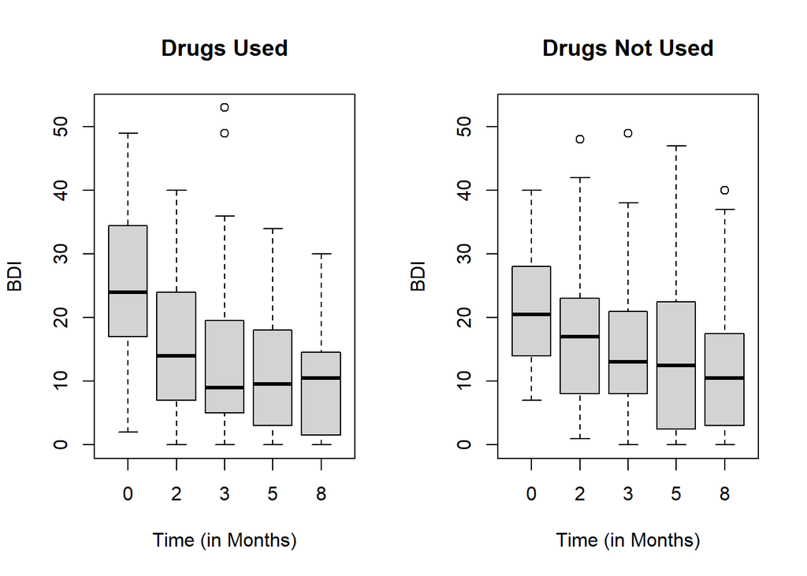

```r
library("gee")
library("lme4")
library("Matrix")
library("multcomp")
library (HSAUR3)
library(ggplot2)
library(plyr)
library(tidyr)

# Construct boxplots to compare the factor variable \textbf{drug} in an
# analogous way to how we constructed boxplots for the treatment
# variable.
data("BtheB")

layout(matrix(1:2, nrow=1))

ylim=range(BtheB[ , grep("bdi", names(BtheB))],
           na.rm=TRUE)

yes=subset(BtheB, drug=="Yes")[ , grep("bdi", names(BtheB))]
boxplot(yes, main="Drugs Used", ylab="BDI",
        xlab="Time (in Months)", names=c(0,2,3,5,8),
        ylim=ylim)

no=subset(BtheB, drug=="No")[ , grep("bdi", names(BtheB))]
boxplot(no, main="Drugs Not Used", ylab="BDI",
        xlab="Time (in Months)", names=c(0,2,3,5,8),
        ylim=ylim)
```

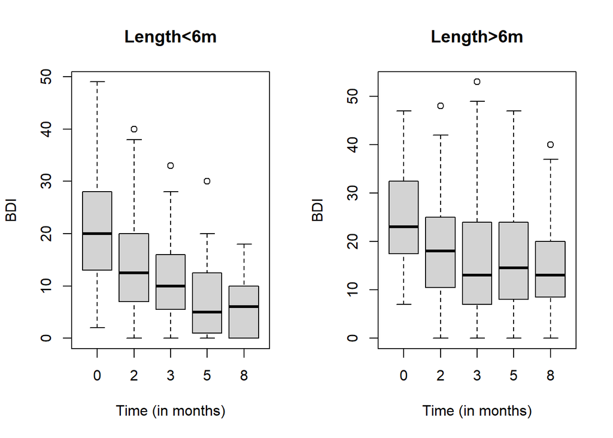

```r
#Repeat for the length variable. Discuss the results.
layout(matrix(1:2, nrow = 1))
lengthlow<-subset(BtheB,length=="<6m")[,grep("bdi",names(BtheB))]
boxplot(lengthlow, main ="Length<6m", ylab= "BDI", xlab = "Time (in months)",names=c(0,2,3,5,8))

lengthhigh<-subset(BtheB,length==">6m")[,grep("bdi",names(BtheB))]
boxplot(lengthhigh, main ="Length>6m", ylab= "BDI", xlab = "Time (in months)",names=c(0,2,3,5,8))
```

Next, we will use the $\textit{lm}$ function to fit a model to the Beat the Blues data that assumes that the repeated measurements are independent. Compare the results to those from fitting the random intercept model $\textit{BtheB\_lmer1}$.

```r
BtheB$subject=factor(rownames(BtheB))
nobs=nrow(BtheB)
cat("Let change the data in wide format")
```

```
## Let change the data in wide format
```

```r
BtheB_long=reshape(BtheB, idvar = "subject",
                   varying = c("bdi.2m", "bdi.3m", "bdi.5m", "bdi.8m"),
                   direction = "long")
BtheB_long$time=rep(c(2, 3, 5, 8), rep(nobs, 4))


BtheB_lm=lm(bdi ~ bdi.pre + time + treatment + drug +
              length, data=BtheB_long, na.action=na.omit)

summary(BtheB_lm)
```

```
##
## Call:
## lm(formula = bdi ~ bdi.pre + time + treatment + drug + length,
##     data = BtheB_long, na.action = na.omit)
##
## Residuals:
##      Min       1Q   Median       3Q      Max
## -23.6779  -5.4177   0.0151   5.3268  27.2688
##
## Coefficients:
##                Estimate Std. Error t value Pr(>|t|)
## (Intercept)     7.32290    1.72765   4.239 3.08e-05 ***
## bdi.pre         0.57396    0.05497  10.440  < 2e-16 ***
## time           -0.93784    0.23650  -3.965 9.36e-05 ***
## treatmentBtheB -3.32254    1.10069  -3.019  0.00278 **
## drugYes        -3.56866    1.14717  -3.111  0.00206 **
## length>6m       1.71067    1.11056   1.540  0.12463
## ---
## Signif. codes:  0 '***' 0.001 '**' 0.01 '*' 0.05 '.' 0.1 ' ' 1
##
## Residual standard error: 8.674 on 274 degrees of freedom
##   (120 observations deleted due to missingness)
## Multiple R-squared:  0.395,  Adjusted R-squared:  0.384
## F-statistic: 35.78 on 5 and 274 DF,  p-value: < 2.2e-16
```

```r
BtheB_lmer1=lmer(bdi ~ bdi.pre + time + treatment + drug +
                   length + (1 | subject), data=BtheB_long,
                 REML=FALSE, na.action=na.omit)

cftest(BtheB_lmer1)
```

```
##
##   Simultaneous Tests for General Linear Hypotheses
##
## Fit: lmer(formula = bdi ~ bdi.pre + time + treatment + drug + length +
##     (1 | subject), data = BtheB_long, REML = FALSE, na.action = na.omit)
##
## Linear Hypotheses:
##                     Estimate Std. Error z value Pr(>|z|)
## (Intercept) == 0     5.59239    2.24244   2.494   0.0126 *
## bdi.pre == 0         0.63968    0.07789   8.212 2.22e-16 ***
## time == 0           -0.70476    0.14639  -4.814 1.48e-06 ***
## treatmentBtheB == 0 -2.32908    1.67036  -1.394   0.1632
## drugYes == 0        -2.82495    1.72684  -1.636   0.1019
## length>6m == 0       0.19708    1.63832   0.120   0.9043
## ---
## Signif. codes:  0 '***' 0.001 '**' 0.01 '*' 0.05 '.' 0.1 ' ' 1
## (Univariate p values reported)
```

```r
cat("Comparison of lm and lmer")
```

```
## Comparison of lm and lmer
```

```r
anova(BtheB_lmer1,BtheB_lm)
```

```
## Data: BtheB_long
## Models:
## BtheB_lm: bdi ~ bdi.pre + time + treatment + drug + length
## BtheB_lmer1: bdi ~ bdi.pre + time + treatment + drug + length + (1 | subject)
##             npar    AIC    BIC  logLik deviance Chisq Df Pr(>Chisq)
## BtheB_lm       7 2012.3 2037.7 -999.15   1998.3
## BtheB_lmer1    8 1887.5 1916.6 -935.75   1871.5 126.8  1  < 2.2e-16 ***
## ---
## Signif. codes:  0 '***' 0.001 '**' 0.01 '*' 0.05 '.' 0.1 ' ' 1
```

```r
cat("We can plot the residuals from Linear model")
```

```
## We can plot the residuals from Linear model
```

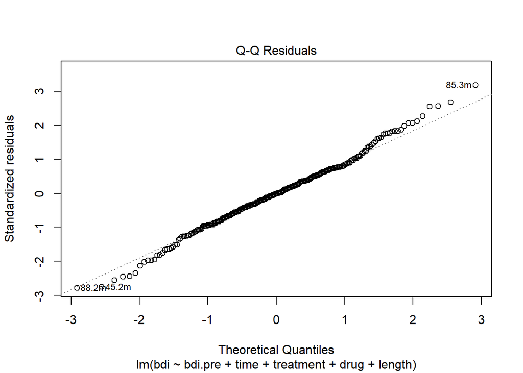

```r
plot(BtheB_lm, which=2)
```

```r
# Assumptions for Mixed-model

residuals <- function(object, obs) obs-predict(object)
cat("We can also plot the residuals from linear mixed-model")
```

```
## We can also plot the residuals from linear mixed-model
```

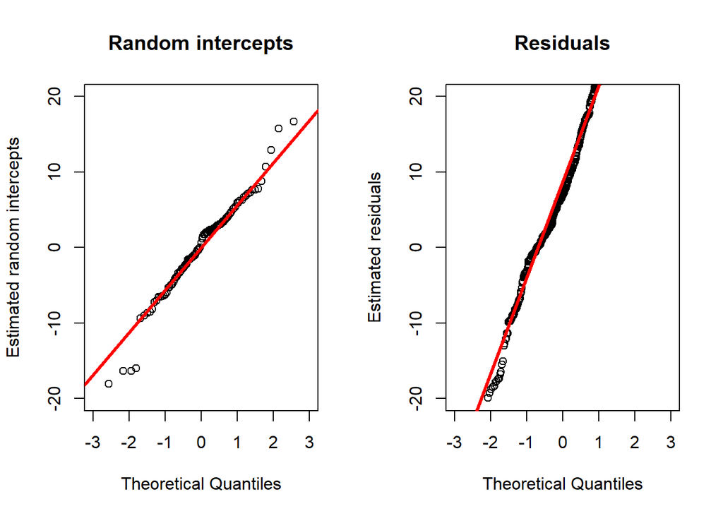

```r
layout(matrix(1:2, ncol = 2))
qint <- ranef(BtheB_lmer1)$subject[["(Intercept)"]]
qres <- residuals(BtheB_lmer1,BtheB_long$bdi.pre)
qqnorm(qint, ylab = "Estimated random intercepts",
     xlim = c(-3, 3), ylim = c(-20, 20),
     main = "Random intercepts")
qqline(qint, col="red", lwd=3)
qqnorm(qres, xlim = c(-3, 3), ylim = c(-20, 20),
     ylab = "Estimated residuals",
     main = "Residuals")
qqline(qres, col="red", lwd=3)
```

In linear model, Bdi.pre, time, treatmentBtheB, and drugYes are significant, but in the lmer model, only bdi.pre and time are significant. This means that the linear model understates the standard errors because it does not account for the correlation over time or the repeated measures.

In the first output, the linear model shows that there is interation between time and treatment with P < 0.05. However, mixed effect model (lmer) indicates that there is no time and treatment effect because p is 0.09.

Next, we will investigate and discuss whether there is any evidence of an interaction between treatment and time for the Beat the Blues data.

```r
# Investigate and discuss whether there is any evidence of an interaction
# between treatment and time for the Beat the Blues data.

cat("Testing fitted linear model with lm")
```

```
## Testing fitted linear model with lm
```

```r
BtheB_lm2=lm(bdi ~ bdi.pre + time + treatment + drug +
                   length + time*treatment + subject,
                 data=BtheB_long, REML=FALSE, na.action=na.omit)
summary(BtheB_lm2)
```

```
##
## Call:
## lm(formula = bdi ~ bdi.pre + time + treatment + drug + length +
##     time * treatment + subject, data = BtheB_long, na.action = na.omit,
##     REML = FALSE)
##
## Residuals:
##     Min      1Q  Median      3Q     Max
## -12.142  -2.135   0.000   1.475  18.851
##
## Coefficients: (4 not defined because of singularities)
##                      Estimate Std. Error t value Pr(>|t|)
## (Intercept)          29.76770    9.56265   3.113 0.002154 **
## bdi.pre              -1.65000    0.70622  -2.336 0.020565 *
## time                 -0.95949    0.21348  -4.494 1.24e-05 ***
## treatmentBtheB      -19.42712   11.68602  -1.662 0.098158 .
## drugYes               6.00000    3.53108   1.699 0.091000 .
## length>6m            22.48102   12.10631   1.857 0.064941 .
## subject10             3.10000    4.52199   0.686 0.493881
## subject11            19.06898    4.40270   4.331 2.45e-05 ***
## subject12           100.14125   35.32423   2.835 0.005105 **
## subject13            18.05000    5.42455   3.327 0.001061 **
## subject14            23.31898    5.41836   4.304 2.75e-05 ***
## subject15            15.80000    6.07510   2.601 0.010070 *
## subject16             5.45000    4.11791   1.323 0.187343
## subject17            46.96818   12.31014   3.815 0.000186 ***
## subject18            19.78102   12.16794   1.626 0.105760
## subject19            42.11898    7.12772   5.909 1.67e-08 ***
## subject2             34.65000   11.83833   2.927 0.003862 **
## subject20            52.83102   25.34385   2.085 0.038512 *
## subject21             8.46022    7.50845   1.127 0.261336
## subject22            33.95000    9.83645   3.451 0.000694 ***
## subject23            14.00000    4.99370   2.804 0.005606 **
## subject24             3.67026    8.82128   0.416 0.677853
## subject25            27.12026    6.73771   4.025 8.36e-05 ***
## subject26            11.81818    5.55378   2.128 0.034694 *
## subject27             0.95128    6.84960   0.139 0.889699
## subject28            62.16624   12.24689   5.076 9.51e-07 ***
## subject29            24.00000   14.55901   1.648 0.100992
## subject3             27.40128    9.26385   2.958 0.003511 **
```

[output cut: 67 more lines]

```
## subject92            60.94920   22.05961   2.763 0.006320 **
## subject93            21.76246   13.32765   1.633 0.104232
## subject94             3.20000    4.94351   0.647 0.518249
## subject95                  NA         NA      NA       NA
## subject96                  NA         NA      NA       NA
## subject98                  NA         NA      NA       NA
## subject99                  NA         NA      NA       NA
## time:treatmentBtheB   0.64358    0.29757   2.163 0.031867 *
## ---
## Signif. codes:  0 '***' 0.001 '**' 0.01 '*' 0.05 '.' 0.1 ' ' 1
##
## Residual standard error: 4.994 on 181 degrees of freedom
##   (120 observations deleted due to missingness)
## Multiple R-squared:  0.8675, Adjusted R-squared:  0.7958
## F-statistic:  12.1 on 98 and 181 DF,  p-value: < 2.2e-16
```

```r
cat("Testing fitted linear mixed-model with lmer subject as a random effect")
```

```
## Testing fitted linear mixed-model with lmer subject as a random effect
```

```r
BtheB_lmer2=lmer(bdi ~ bdi.pre + time + treatment + drug +
                   length + time*treatment + (1 | subject),
                 data=BtheB_long, REML=FALSE, na.action=na.omit)

cftest(BtheB_lmer2)
```

```
##
##   Simultaneous Tests for General Linear Hypotheses
##
## Fit: lmer(formula = bdi ~ bdi.pre + time + treatment + drug + length +
##     time * treatment + (1 | subject), data = BtheB_long, REML = FALSE,
##     na.action = na.omit)
##
## Linear Hypotheses:
##                          Estimate Std. Error z value Pr(>|z|)
## (Intercept) == 0          6.47824    2.31905   2.793  0.00521 **
## bdi.pre == 0              0.64046    0.07843   8.166 2.22e-16 ***
## time == 0                -0.95555    0.20831  -4.587 4.49e-06 ***
## treatmentBtheB == 0      -4.09804    1.98490  -2.065  0.03896 *
## drugYes == 0             -2.79209    1.73986  -1.605  0.10854
## length>6m == 0            0.21905    1.65043   0.133  0.89441
## time:treatmentBtheB == 0  0.49000    0.28959   1.692  0.09064 .
## ---
## Signif. codes:  0 '***' 0.001 '**' 0.01 '*' 0.05 '.' 0.1 ' ' 1
## (Univariate p values reported)
```

Now, we will create a plot of the mean profiles of both treatment groups in the Beat the Blues data, showing also standard deviation bars at each time point.

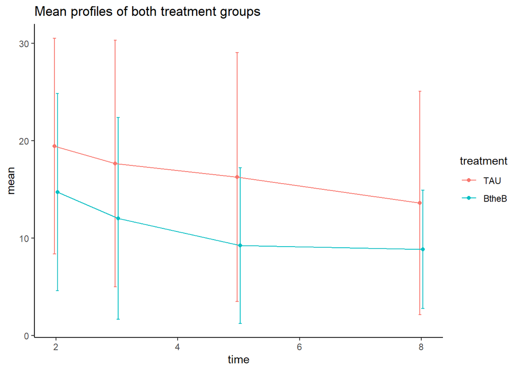

```r
# Create a plot of the mean profiles of both treatment groups in the Beat
# the Blues data, showing also standard deviation bars at each time point.
data_sum=ddply(BtheB_long, c("time", "treatment"), summarise,
            N=sum(!is.na(bdi)),
            mean=mean(bdi, na.rm=TRUE),
            sd=sd(bdi, na.rm=TRUE),
            se=sd/sqrt(N))

pd <- position_dodge(0.1)

ggplot(data_sum, aes(x=time, y=mean, colour=treatment)) +
  geom_errorbar(aes(ymin=mean-sd, ymax=mean+sd), width=0.1, position=pd) +
  geom_line(position=pd) +
  geom_point(position=pd) +
  theme_classic() +
  labs(title = "Mean profiles of both treatment groups")
```

The mean profile shows that the results are very different between the two categories, but the standard deviation bars converge.

Now, consider the $\textbf{phosphate}$ data from the package `HSAUR3`. This data shows the plasma inorganic phosphate levels for 33 subjects, 20 of whom are controls and 13 of whom have been classified as obese (Davis, 2002). First, we will create boxplots by group and discuss the results below.

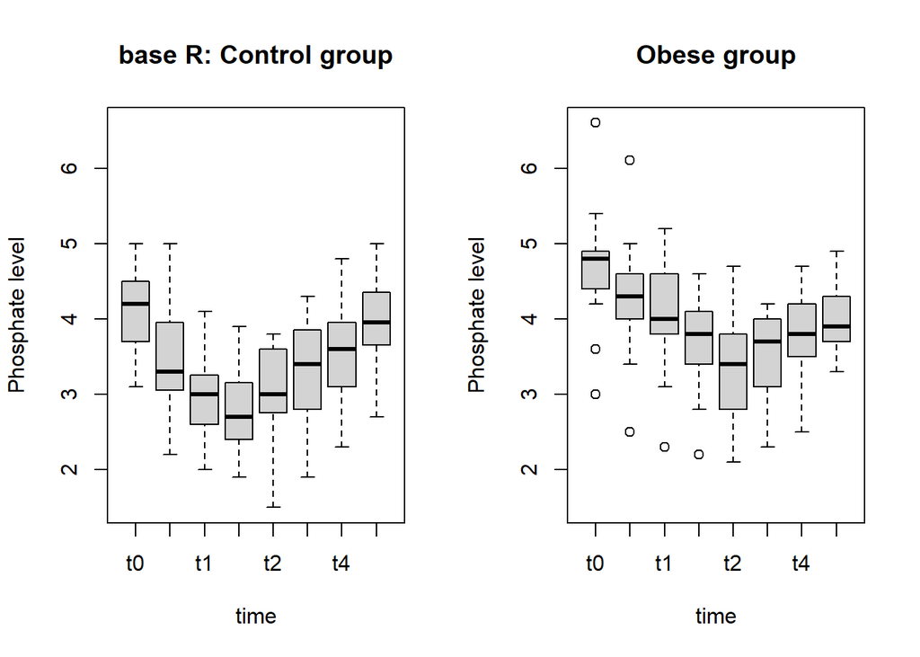

```r
data("phosphate", package = "HSAUR3")
library(lme4)
library(Matrix)
library(multcomp)
attach(phosphate)
par(mfrow = c(1,2))
ylim <-range(phosphate[,-1], na.rm = TRUE)
# Construct boxplots by group and discuss.
boxplot(phosphate[group == "control", -1],
        xlab = "time", ylab = "Phosphate level",
        main = "base R: Control group", ylim = ylim)
boxplot(phosphate[group == "obese",-1],
        xlab = "time", ylab = "Phosphate level",
        main = "Obese group", ylim = ylim)
```

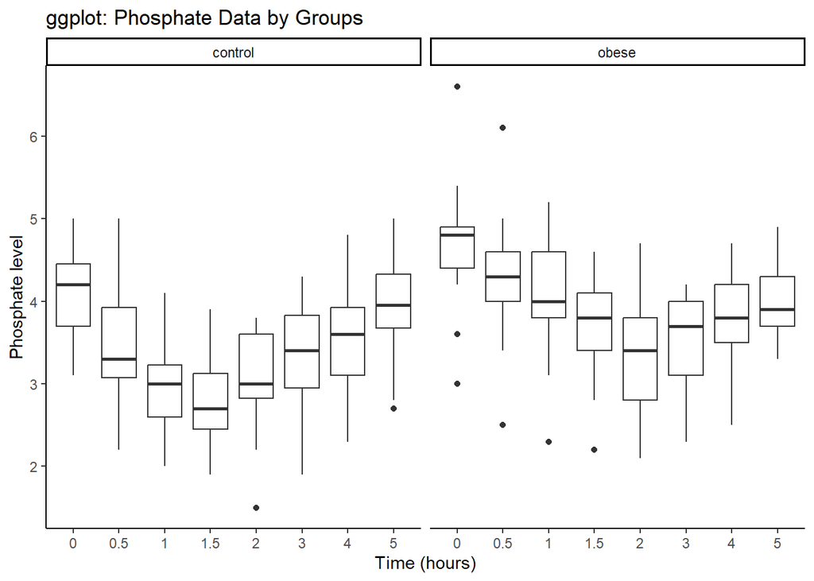

```r
# ggplot version:
phosphate %>%
  gather(time,phosphate_level, 2:9) %>%
  mutate(time = factor(gsub(time,pattern="[[:alpha:]]",replacement=''))) %>%
ggplot(aes(x=time,y=phosphate_level)) +
  geom_boxplot() +
  facet_grid(.~group) +
  labs(title='ggplot: Phosphate Data by Groups',
       x='Time (hours)',
       y='Phosphate level') +
  theme_classic()
```

Next, we will create separate plots of the profiles of the individuals in each group.

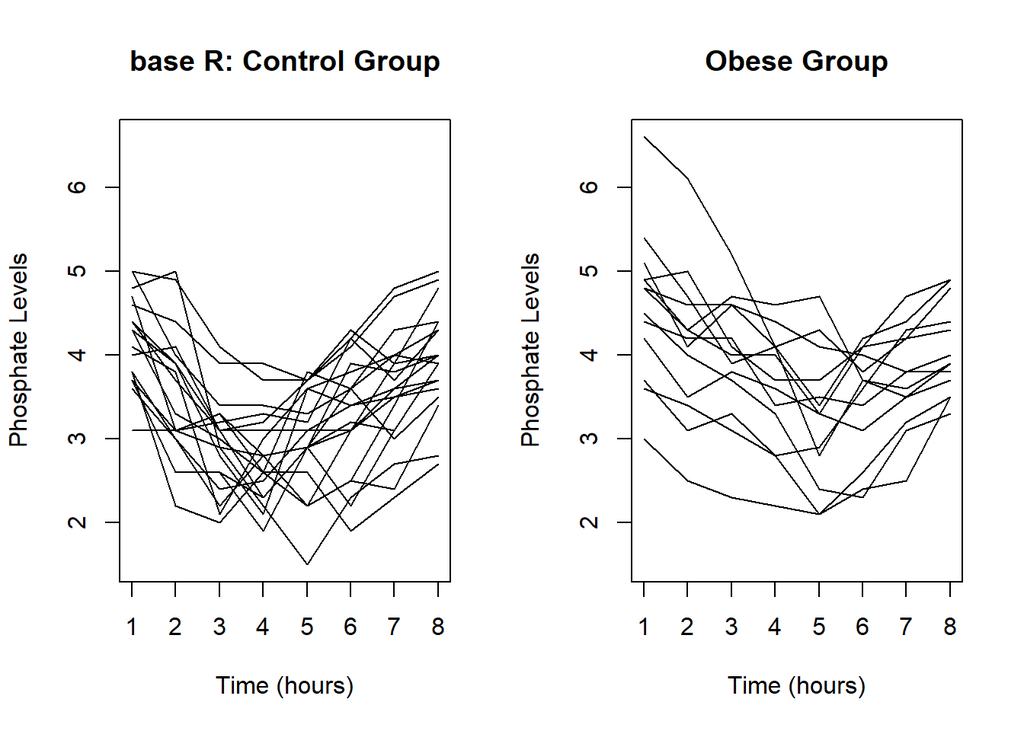

```r
# Produce separate plots of the profiles of the individuals in each group
layout(matrix(1:2, nrow=1))

rg=range(phosphate[ ,-1])
plot(c(1, 8), c(rg), type="n", xlab="Time (hours)",
     ylab="Phosphate Levels", main="base R: Control Group")
for(i in 1:sum(phosphate$group=="control")){
  lines(1:8, phosphate[i, -1])
}

plot(c(1, 8), c(rg), type="n", xlab="Time (hours)",
     ylab="Phosphate Levels", main="Obese Group")
for(i in 1:sum(phosphate$group=="obese")){
  lines(1:8, phosphate[nrow(phosphate)-i, -1])
}
```

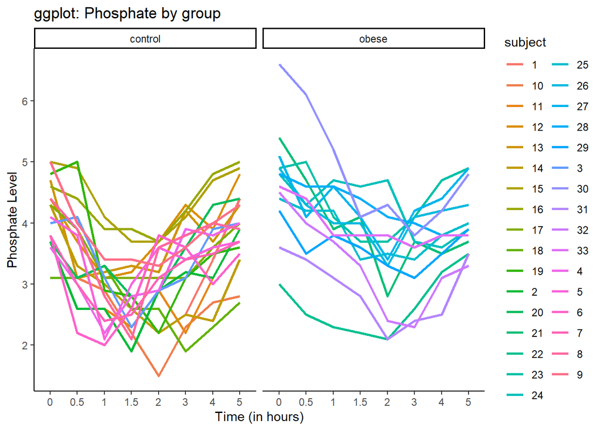

```r
phosphate_t <- phosphate
phosphate_t$subject <- factor(rownames(phosphate_t))

phosphate_t %>%
  gather(time,phosphate_level, 2:9) %>%
  mutate(time = factor(gsub(time,pattern="[[:alpha:]]",replacement=''))) %>%
ggplot(aes(x=time,y=phosphate_level)) +
  geom_line(aes(group=subject,color=subject),size=1) +
  facet_grid(.~group) +
  labs(title='ggplot: Phosphate by group',
       x='Time (in hours)',
       y='Phosphate Level') +
  theme_classic()
```

Guided by how these plots fit, we may be interested to find out which linear mixed effects models might be sensible based on the intercept and slope, intercept and interaction.

Here, linear mixed model would be suitable because the slopes and intercepts in each group vary widely. Additionally, there is an interaction between control and obese groups based on time. So fitting something of the form $\textit{lmer(phosphatelevel t0+time∗group+(1= phos)}$ would be suitable.

In the fixed effect model, we see that there is a positive relation between the time and the phosphate level. It makes sense sinse we saw that after decreasing for a while the phosphate level increases for longer than decreasing time period. Based on the f-test with cftest , time, group, baseline phosphate level and the interaction between time and group all are significant.

Next, we will convert the data to long version and fit the model of your choice and discuss the results.

```r
# Convert the data to long version and fit the model
data(phosphate)
ph=phosphate
ph$subject=as.factor(rownames(ph))
##LOng form
a=ph[,c(3:9)]

ph_long=reshape(ph,idvar="subject",v.names="p_level",
                varying=list(names(a)),direction="long")

timer=seq(1:7)
timer[1]=0.5
timer[2]=1
timer[3]=1.5
for(i in 4:7){
  timer[i]=i-2}

for(i in 1:7){
  for(j in 1:33){
    ph_long[(33*(i-1)+j),4]=timer[i]
  }
}

ph_non_inter=lmer(p_level~time+group+t0+(1|subject),data=ph_long,
                  REML=FALSE,na.actio=na.omit)

ph_inter=lmer(p_level~time+group+t0+time*group+(1|subject),
              data=ph_long,REML=FALSE,na.actio=na.omit)

ph_cept_slope=lmer(p_level~time+group+t0+
                     (time|subject),
              data=ph_long,REML=FALSE,na.actio=na.omit)

ph_cept_slope_inter=lmer(p_level~time+group+t0+time*group+
                           (time|subject),
                         data=ph_long,REML=FALSE,na.actio=na.omit)

print(summary(ph_cept_slope_inter))
```

```
## Linear mixed model fit by maximum likelihood  ['lmerMod']
## Formula: p_level ~ time + group + t0 + time * group + (time | subject)
##    Data: ph_long
##
##      AIC      BIC   logLik deviance df.resid
##    391.4    422.4   -186.7    373.4      222
##
## Scaled residuals:
##     Min      1Q  Median      3Q     Max
## -2.4110 -0.5834 -0.0418  0.5864  3.5255
##
## Random effects:
##  Groups   Name        Variance Std.Dev. Corr
##  subject  (Intercept) 0.00921  0.09597
##           time        0.00451  0.06716  1.00
##  Residual             0.25005  0.50005
## Number of obs: 231, groups:  subject, 33
##
## Fixed effects:
##                  Estimate Std. Error t value
## (Intercept)      0.001776   0.339779   0.005
## time             0.174229   0.031569   5.519
## groupobese       0.636604   0.137837   4.619
## t0               0.691589   0.079429   8.707
## time:groupobese -0.211030   0.050297  -4.196
##
## Correlation of Fixed Effects:
##             (Intr) time   gropbs t0
## time        -0.145
## groupobese   0.149  0.356
## t0          -0.970  0.000 -0.304
## time:gropbs  0.091 -0.628 -0.568  0.000
## optimizer (nloptwrap) convergence code: 0 (OK)
## boundary (singular) fit: see help('isSingular')
```

```r
print(cftest(ph_cept_slope_inter))
```

```
##
##   Simultaneous Tests for General Linear Hypotheses
##
## Fit: lmer(formula = p_level ~ time + group + t0 + time * group + (time |
##     subject), data = ph_long, REML = FALSE, na.action = na.omit)
##
## Linear Hypotheses:
##                       Estimate Std. Error z value Pr(>|z|)
## (Intercept) == 0      0.001776   0.339779   0.005    0.996
## time == 0             0.174229   0.031569   5.519 3.41e-08 ***
## groupobese == 0       0.636604   0.137837   4.619 3.86e-06 ***
## t0 == 0               0.691589   0.079429   8.707  < 2e-16 ***
## time:groupobese == 0 -0.211030   0.050297  -4.196 2.72e-05 ***
## ---
## Signif. codes:  0 '***' 0.001 '**' 0.01 '*' 0.05 '.' 0.1 ' ' 1
## (Univariate p values reported)
```

```r
anova(ph_inter,ph_non_inter,ph_cept_slope,ph_cept_slope_inter)
```

```
## Data: ph_long
## Models:
## ph_non_inter: p_level ~ time + group + t0 + (1 | subject)
## ph_inter: p_level ~ time + group + t0 + time * group + (1 | subject)
## ph_cept_slope: p_level ~ time + group + t0 + (time | subject)
## ph_cept_slope_inter: p_level ~ time + group + t0 + time * group + (time | subject)
##                     npar    AIC    BIC  logLik deviance  Chisq Df Pr(>Chisq)
## ph_non_inter           6 411.77 432.43 -199.89   399.77
## ph_inter               7 393.19 417.29 -189.59   379.19 20.585  1  5.705e-06
## ph_cept_slope          8 404.23 431.76 -194.11   388.23  0.000  1  1.0000000
## ph_cept_slope_inter    9 391.45 422.43 -186.72   373.45 14.776  1  0.0001211
##
## ph_non_inter
## ph_inter            ***
## ph_cept_slope
## ph_cept_slope_inter ***
## ---
## Signif. codes:  0 '***' 0.001 '**' 0.01 '*' 0.05 '.' 0.1 ' ' 1
```

```r
pred=predict(ph_cept_slope_inter)
MSE=mean((pred-ph_long$p_level)^2)
message("Mean Squared Error: ",MSE)
message("Mean Phosphate Level: ",mean(ph_long$p_level))
```

[output not shown]

Comparing this with three other models, (ph_non_inter=random intercept, ph_inter=random intercept with interaction, ph_cept_slope=random intercept and random slope) using anova, the model used here has the smallest AIC (about 391) indicating a better fit of among four models. However, considering BIC value, we also see that random intercept with interaction is also a good model.

## Part 2

Now, consider the $\textbf{respiratory}$ data from the $\textbf{HSAUR3}$ package. Then, investigate the use of other correlational structures than the independence and exchangeable structures used in the text for the respiratory data.

```r
library(HSAUR3)
library(gee)
library(geepack)
library(lme4)
library(MuMIn)
library(multcomp)

cat("1a")
```

```
## 1a
```

```r
data("respiratory", package="HSAUR3")
head(respiratory)
```

```
##     centre treatment gender age status month subject
## 1        1   placebo female  46   poor     0       1
## 112      1   placebo female  46   poor     1       1
## 223      1   placebo female  46   poor     2       1
## 334      1   placebo female  46   poor     3       1
## 445      1   placebo female  46   poor     4       1
## 2        1   placebo female  28   poor     0       2
```

```r
dim(respiratory)
```

```
## [1] 555   7
```

```r
resp_sub <- subset(respiratory, month > "0")
resp_sub$baseline <- rep(subset(respiratory, month == "0")$status,rep(4, 111))

resp_sub$nstat <- as.numeric(resp_sub$status == "good")
resp_sub$month <- resp_sub$month[, drop = TRUE]
head(resp_sub, n = 3)
```

```
##     centre treatment gender age status month subject baseline nstat
## 112      1   placebo female  46   poor     1       1     poor     0
## 223      1   placebo female  46   poor     2       1     poor     0
## 334      1   placebo female  46   poor     3       1     poor     0
```

```r
names(resp_sub)[names(resp_sub) == "treatment"] <- "trt"
levels(resp_sub$trt)[2] <- "trt"

cat("Now, fitting the models")
```

```
## Now, fitting the models
```

```r
resp_sub_glm <- glm(status ~ centre + trt + gender + baseline + age, data = resp_sub, family = "binomial")

resp_sub_gee1 <- gee(nstat ~ centre + trt+ gender + baseline + age, data = resp_sub, family = "binomial", id = subject, corstr = "independence", scale.fix = TRUE, scale.value = 1)
```

```
##  (Intercept)      centre2       trttrt   gendermale baselinegood          age
##  -0.90017133   0.67160098   1.29921589   0.11924365   1.88202860  -0.01816588
```

```r
resp_sub_gee2 <- gee(nstat ~ centre + trt + gender + baseline + age, data =resp_sub, family = "binomial", id = subject, corstr = "exchangeable", scale.fix = TRUE, scale.value = 1)
```

```
##  (Intercept)      centre2       trttrt   gendermale baselinegood          age
##  -0.90017133   0.67160098   1.29921589   0.11924365   1.88202860  -0.01816588
```

```r
resp_sub_gee3 <- gee(nstat ~ centre + trt + gender + baseline + age, data =resp_sub, family = "binomial", id = subject, corstr = "unstructured", scale.fix = TRUE, scale.value = 1)
```

```
##  (Intercept)      centre2       trttrt   gendermale baselinegood          age
##  -0.90017133   0.67160098   1.29921589   0.11924365   1.88202860  -0.01816588
```

```r
resp_sub_gee4 <- gee(nstat ~ centre + trt + gender + baseline + age, data =resp_sub, family = "binomial", id = subject, corstr = "AR-M", scale.fix = TRUE, scale.value = 1)
```

```
##  (Intercept)      centre2       trttrt   gendermale baselinegood          age
##  -0.90017133   0.67160098   1.29921589   0.11924365   1.88202860  -0.01816588
```

```r
cat(" Summary")
```

```
##  Summary
```

```r
knitr::kable(summary(resp_sub_glm)$coeff, caption = "Summary coeff of GLM binomial")
```

Summary coeff of GLM binomial

|  | Estimate | Std. Error | z value | Pr(>\|z\|) |
| --- | --- | --- | --- | --- |
| (Intercept) | -0.9001713 | 0.3376530 | -2.6659658 | 0.0076767 |
| centre2 | 0.6716010 | 0.2395666 | 2.8034004 | 0.0050567 |
| trttrt | 1.2992159 | 0.2368410 | 5.4856047 | 0.0000000 |
| gendermale | 0.1192436 | 0.2946710 | 0.4046671 | 0.6857223 |
| baselinegood | 1.8820286 | 0.2412902 | 7.7998563 | 0.0000000 |
| age | -0.0181659 | 0.0088644 | -2.0493065 | 0.0404322 |

```r
knitr::kable(summary(resp_sub_gee1)$coef, caption = "Summary coeff of GEE binomial independent")
```

Summary coeff of GEE binomial independent

|  | Estimate | Naive S.E. | Naive z | Robust S.E. | Robust z |
| --- | --- | --- | --- | --- | --- |
| (Intercept) | -0.9001713 | 0.3376531 | -2.665965 | 0.4603270 | -1.9555041 |
| centre2 | 0.6716010 | 0.2395666 | 2.803400 | 0.3568191 | 1.8821889 |
| trttrt | 1.2992159 | 0.2368410 | 5.485603 | 0.3507780 | 3.7038127 |
| gendermale | 0.1192436 | 0.2946710 | 0.404667 | 0.4432023 | 0.2690501 |
| baselinegood | 1.8820286 | 0.2412902 | 7.799855 | 0.3500515 | 5.3764332 |
| age | -0.0181659 | 0.0088644 | -2.049306 | 0.0130043 | -1.3969169 |

```r
knitr::kable(summary(resp_sub_gee2)$coef, caption = "Summary coeff of GEE binomial exchangeable")
```

Summary coeff of GEE binomial exchangeable

|  | Estimate | Naive S.E. | Naive z | Robust S.E. | Robust z |
| --- | --- | --- | --- | --- | --- |
| (Intercept) | -0.9001713 | 0.4784634 | -1.8813796 | 0.4603270 | -1.9555041 |
| centre2 | 0.6716010 | 0.3394723 | 1.9783676 | 0.3568191 | 1.8821889 |
| trttrt | 1.2992159 | 0.3356101 | 3.8712064 | 0.3507780 | 3.7038127 |
| gendermale | 0.1192436 | 0.4175568 | 0.2855747 | 0.4432023 | 0.2690501 |
| baselinegood | 1.8820286 | 0.3419147 | 5.5043802 | 0.3500515 | 5.3764332 |
| age | -0.0181659 | 0.0125611 | -1.4462014 | 0.0130043 | -1.3969169 |

```r
knitr::kable(summary(resp_sub_gee3)$coef, caption = "Summary coeff of GEE binomial unstructured")
```

Summary coeff of GEE binomial unstructured

|  | Estimate | Naive S.E. | Naive z | Robust S.E. | Robust z |
| --- | --- | --- | --- | --- | --- |
| (Intercept) | -0.9312798 | 0.4791852 | -1.9434655 | 0.4612499 | -2.0190352 |
| centre2 | 0.6727947 | 0.3390779 | 1.9841895 | 0.3548202 | 1.8961568 |
| trttrt | 1.2789154 | 0.3354409 | 3.8126404 | 0.3494500 | 3.6597956 |
| gendermale | 0.0946735 | 0.4172964 | 0.2268736 | 0.4436295 | 0.2134068 |
| baselinegood | 1.9346252 | 0.3428184 | 5.6432949 | 0.3480468 | 5.5585200 |
| age | -0.0168892 | 0.0125574 | -1.3449620 | 0.0129054 | -1.3086948 |

```r
knitr::kable(summary(resp_sub_gee4)$coef, caption = "Summary coeff of GEE binomial AR-M")
```

Summary coeff of GEE binomial AR-M

|  | Estimate | Naive S.E. | Naive z | Robust S.E. | Robust z |
| --- | --- | --- | --- | --- | --- |
| (Intercept) | -0.9629448 | 0.4455161 | -2.1614142 | 0.4611607 | -2.0880894 |
| centre2 | 0.7427015 | 0.3146448 | 2.3604438 | 0.3562300 | 2.0848932 |
| trttrt | 1.2472824 | 0.3112665 | 4.0071210 | 0.3518974 | 3.5444492 |
| gendermale | 0.1132323 | 0.3883671 | 0.2915599 | 0.4494506 | 0.2519348 |
| baselinegood | 1.9113953 | 0.3167921 | 6.0335952 | 0.3501873 | 5.4582088 |
| age | -0.0169164 | 0.0116652 | -1.4501525 | 0.0129273 | -1.3085816 |

Looking at the difference between Naive z and Robust z with relevant variables for the above models, resp_sub_gee3 with unstructured comparison correlation structure model tends to have a minimal difference between Naive z and Robust z than others. Therefore, in this case, unstructured model fits best.

Which model is the best? Compare the following models: independent, exchangable, and what ever models we tried previously. Perhaps we can use QIC (in ), MSE, misclassification rate, comparison of naive vs robust Z-score, or another method.

```
## Fitting GEE Independent
```

QIC from GGE independent

|  | x |
| --- | --- |
| QIC | 508.5300 |
| QICu | 495.2182 |
| Quasi Lik | -241.6091 |
| CIC | 12.6559 |
| params | 6.0000 |
| QICC | 509.3377 |

```
## Fitting GEE Exchangeable
```

QIC from GGE exchangeable

|  | x |
| --- | --- |
| QIC | 508.5300 |
| QICu | 495.2182 |
| Quasi Lik | -241.6091 |
| CIC | 12.6559 |
| params | 6.0000 |
| QICC | 509.6173 |

```
## Fitting GEE Unstructured
```

QIC from GGE Unstructured

|  | x |
| --- | --- |
| QIC | 508.49136 |
| QICu | 495.33613 |
| Quasi Lik | -241.66807 |
| CIC | 12.57762 |
| params | 6.00000 |
| QICC | 511.67504 |

```
## Fitting GEE ar1
```

QIC from GGE ar1

|  | x |
| --- | --- |
| QIC | 509.36674 |
| QICu | 495.64242 |
| Quasi Lik | -241.82121 |
| CIC | 12.86216 |
| params | 6.00000 |
| QICC | 510.45412 |

Now, we will use the dataset $\textbf{schizophrenia2}$ from $\textbf{HSAUR3}$ package. This was collected in a follow-up study of women patients with schizophrenia (Davis, 2002). The binary response recorded at 0, 2, 6, 8 and 10 months after hospitalization was ``thought disorder’’ (absent or present). The single covariate is the factor indicating whether a patient had suffered early or late onset of her condition (age of onset less than 20 years or age of onset 20 years or above).

The question of interest is whether the course of the illness differs between patients with early and late onset schizophrenia. (https://www.rdocumentation.org/packages/HSAUR3/versions/1.0-9/topics/schizophrenia2)

We will now investigate this question using plots and summary statistics

```
## Calculating percentage data
```

Summary statistics for presence of younger onset data

| Min. | 1st Qu. | Median | Mean | 3rd Qu. | Max. |
| --- | --- | --- | --- | --- | --- |
| 0.09375 | 0.15625 | 0.25 | 0.34375 | 0.59375 | 0.625 |

Summary statistics for presence of older onset data

| Min. | 1st Qu. | Median | Mean | 3rd Qu. | Max. |
| --- | --- | --- | --- | --- | --- |
| 0 | 0.0833333 | 0.09375 | 0.2520833 | 0.5 | 0.5833333 |

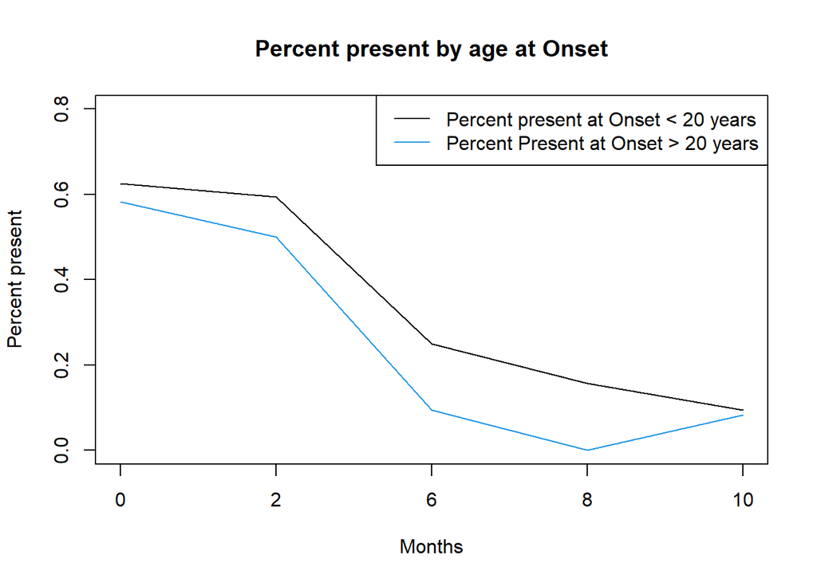

For the older-onset population, the mean and the median of the percentage of’ presence of schizophrenia’ are lower. Looking at the percentage plot, it appears that at each sample date (in months) the percentage is lower in the older-onset population.

Then with the GEE approach:

QIC from GEE Independent (identity)

|  | x |
| --- | --- |
| QIC | 163.788881 |
| QICu | 159.831542 |
| Quasi Lik | -75.915771 |
| CIC | 5.978669 |
| params | 4.000000 |
| QICC | 164.841512 |

QIC from GEE Exchangeable

|  | x |
| --- | --- |
| QIC | 164.011346 |
| QICu | 160.156189 |
| Quasi Lik | -76.078094 |
| CIC | 5.927579 |
| params | 4.000000 |
| QICC | 165.632968 |

QIC from GEE Unstructured

|  | x |
| --- | --- |
| QIC | 164.832126 |
| QICu | 160.652702 |
| Quasi Lik | -76.326351 |
| CIC | 6.089712 |
| params | 4.000000 |
| QICC | 171.707126 |

Then with the mixed effects model (lmer):

```
## [1] "Without interaction term:"
```

```
## [1] "BIC: Fixed Slope :  179.591302394191"
```

```
## [1] "BIC: Random Slope:  184.624563189316"
```

```
## [1] "With interaction term: month v. onset:"
```

```
## [1] "BIC: Fixed Slope :  184.587333241198"
```

```
## [1] "BIC: Random Slope:  189.620890912604"
```

Here, we will try to see if there is a difference between the models and what model(s) work the best. We will do model comparison with ANOVA:

```
## Fixed Slope v. Random Slope (no intaction term)
```

|  | npar | AIC | BIC | logLik | deviance | Chisq | Df | Pr(>Chisq) |
| --- | --- | --- | --- | --- | --- | --- | --- | --- |
| schiz_lmer1 | 6 | 161.1403 | 179.5913 | -74.57013 | 149.1403 | NA | NA | NA |
| schiz_lmer2 | 8 | 160.0232 | 184.6246 | -72.01159 | 144.0232 | 5.117087 | 2 | 0.0774174 |

```
## Interaction Term v. No Interaction Term (fixed slope)
```

|  | npar | AIC | BIC | logLik | deviance | Chisq | Df | Pr(>Chisq) |
| --- | --- | --- | --- | --- | --- | --- | --- | --- |
| schiz_lmer1 | 6 | 161.1403 | 179.5913 | -74.57013 | 149.1403 | NA | NA | NA |
| schiz_lmer3 | 7 | 163.0611 | 184.5873 | -74.53056 | 149.0611 | 0.079143 | 1 | 0.7784622 |

```
## Fixed Slope, No interaction Term v. Random Slope, With interaction term
```

|  | npar | AIC | BIC | logLik | deviance | Chisq | Df | Pr(>Chisq) |
| --- | --- | --- | --- | --- | --- | --- | --- | --- |
| schiz_lmer1 | 6 | 161.1403 | 179.5913 | -74.57013 | 149.1403 | NA | NA | NA |
| schiz_lmer4 | 9 | 161.9443 | 189.6209 | -71.97216 | 143.9443 | 5.195933 | 3 | 0.1579995 |

```
## Random Slope, No interaction term v. Fixed Slope, With interaction term
```

|  | npar | AIC | BIC | logLik | deviance | Chisq | Df | Pr(>Chisq) |
| --- | --- | --- | --- | --- | --- | --- | --- | --- |
| schiz_lmer3 | 7 | 163.0611 | 184.5873 | -74.53056 | 149.0611 | NA | NA | NA |
| schiz_lmer2 | 8 | 160.0232 | 184.6246 | -72.01159 | 144.0232 | 5.037944 | 1 | 0.0247979 |

```
## No interaction term v. Interaction term (random slope)
```

|  | npar | AIC | BIC | logLik | deviance | Chisq | Df | Pr(>Chisq) |
| --- | --- | --- | --- | --- | --- | --- | --- | --- |
| schiz_lmer2 | 8 | 160.0232 | 184.6246 | -72.01159 | 144.0232 | NA | NA | NA |
| schiz_lmer4 | 9 | 161.9443 | 189.6209 | -71.97216 | 143.9443 | 0.0788461 | 1 | 0.7788673 |

```
## Fixed Slope v. Random Slope (with intaction term)
```

|  | npar | AIC | BIC | logLik | deviance | Chisq | Df | Pr(>Chisq) |
| --- | --- | --- | --- | --- | --- | --- | --- | --- |
| schiz_lmer3 | 7 | 163.0611 | 184.5873 | -74.53056 | 149.0611 | NA | NA | NA |
| schiz_lmer4 | 9 | 161.9443 | 189.6209 | -71.97216 | 143.9443 | 5.11679 | 2 | 0.0774289 |

The model with a fixed effect and no interaction term has the lowest BIC score. This would be an indicator that the concept of contact is not likely to add much to the template if anything. The most significant difference based on ANOVA analysis is between random slope, no interaction term and fixed slope, with interaction term (fourth table). This is indicated with a p-score of 0.025 i.e., [P<0.05].